# STATS 32 Session 8: A Crash Course in Statistics and Modeling

Kenneth Tay

Oct 26, 2017

# Announcements

Remaining office hours:

- 27 Oct (tomorrow) 10am-12pm, Sequoia Hall Rm 207
- 2 Nov (Thu) 1130am-1pm, Sequoia Hall Rm 207

# Recap of session 7

- Making maps in R
  - `geom_polygon`
  - `aes(x = long, y = lat, group = group)`
- Joining datasets with `left_join`
  - `df1 %>% left_join(df2, by = "key")`

# Agenda for today

- A crash course in statistics and modeling
  - Hypothesis testing
  - Linear regression

A very high level picture: for technical details, take STATS 60/STATS 101

# Dataset for illustration: Student alcohol consumption

[figure not shown]

(Source: [Kaggle](https://www.kaggle.com/uciml/student-alcohol-consumption))

# Scores by sex: Is there a difference?

Hard to tell from the histograms:

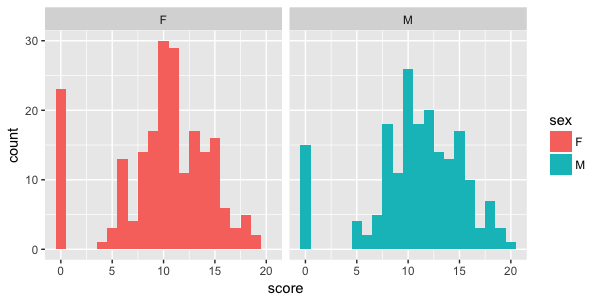

# Look at mean scores

- Female: $\approx 10.0$
- Male: $\approx 10.9$

Is this difference significant? What do we mean by significance anyway?

# Structure of a hypothesis test

> 1. Start with a **null hypothesis**: An assumption on how the data is generated
> 2. Based on this assumption, how likely were we to collect data as extreme as what we have?
> - **p-value**: probability of collecting data as extreme as ours
> 3. Is the p-value considered low or not?
> - Threshold should depend on the context
> - Typical thresholds, 0.1, 0.05, 0.01
> 4. If p-value is below threshold, 2 possible conclusions:
> - A rare event just happened, or
> - Our assumption in Step 1 was false

# Scores by sex: Is there a difference?

2 options:

- $t$-test
  - **Null hypothesis**: Mean score for females is the same as mean score for males
  - Makes more assumptions on the data generation process (“*parametric* test”)
- Kolmogorov-Smirnov test
  - **Null hypothesis**: The distribution of scores for females is the same as the distribution of scores for males
  - Less assumptions on data generation process (“*non-parametric* test”), but rejecting the null gives less information

# What is a model?

- A **model** is a simplified and idealized way to understand a system.
- [R4DS](http://r4ds.had.co.nz/model-intro.html): “The goal of a model is to provide a simple low-dimensional summary of a dataset. Ideally, the model will capture true “signals” (i.e. patterns generated by the phenomenon of interest), and ignore “noise” (i.e. random variation that you’re not interested in).”

# Two steps to modeling

### Step 1: Identify a family of models which express a generic pattern between your variables of interest.

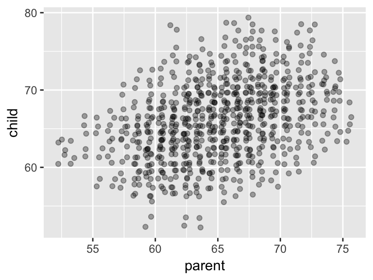

Possible model family: Linear model, i.e. $child = a_1 + a_2 \times parent$.

- Variables: `child` and `parent`
- Model parameters: $a_1$ and $a_2$

Many other possible models: linear without intercept, quadratic, exponential, …

# Different models within the linear model family

Each line corresponds to a choice of $a_1$ and $a_2$.

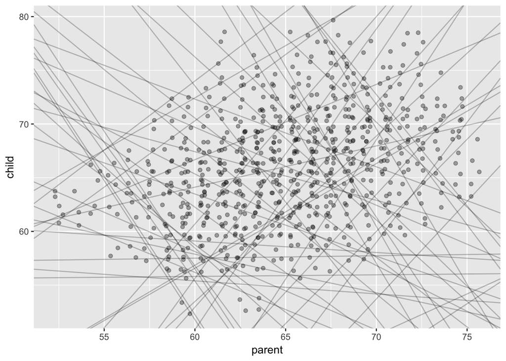

# Two steps to modeling

### Step 2: Find the model in this family that most closely matches your data.

That is, find specific values of $a_1$ and $a_2$ which make the model match the data most closely.

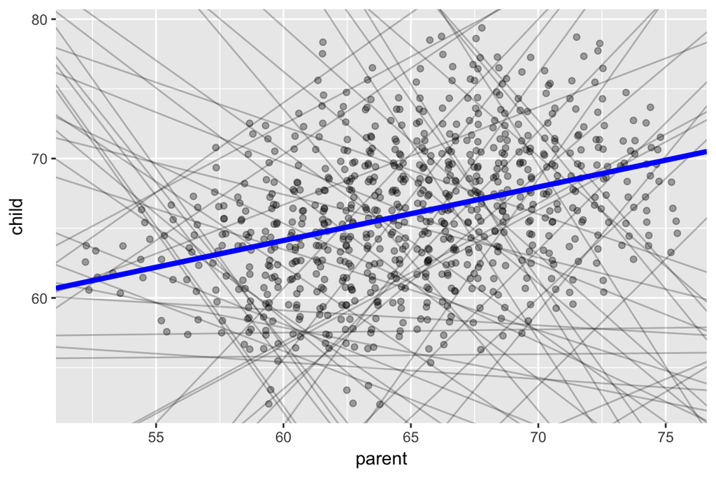

# What do we mean by “closely matching the data”?

We choose $a_1$ and $a_2$ such that some objective function (**loss function**) is minimized.

Most common objective: Minimize the sum of squares of the black lines below.

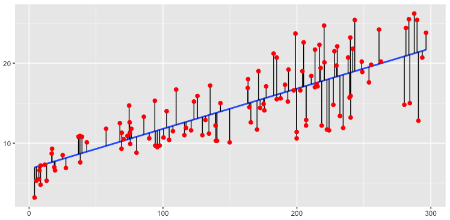

(Source: [uc-r.github.io](http://uc-r.github.io/linear_regression))

# Linear models in R

- Linear regression can be done with the `lm` function
- Syntax: `lm(formula, data = df)`
- Formulas look like `y ~ x`, which `lm` will translate to a function like $y = a_1 + a_2 \cdot x$

# Models with categorical variables

Consider modeling `score ~ sex`.

- Does the model $score = a_1 + a_2 \cdot sex$ make sense?
  - 3 + 4 $\cdot$ “M”??
- What R does:
  - Choose a baseline category (say, “F”)
  - Model $score = a_1 + a_2 \cdot sexM$, where $sexM = \begin{cases} 1 &\text{if "M"}, \\ 0 &\text{if "F"}. \end{cases}$

# Models with categorical variables

- $score = a_1 + a_2 \cdot sexM$, where $sexM = \begin{cases} 1 &\text{if "M"}, \\ 0 &\text{if "F"}. \end{cases}$
- $score = a_1$ if female, $score = a_1 + a_2$ if male

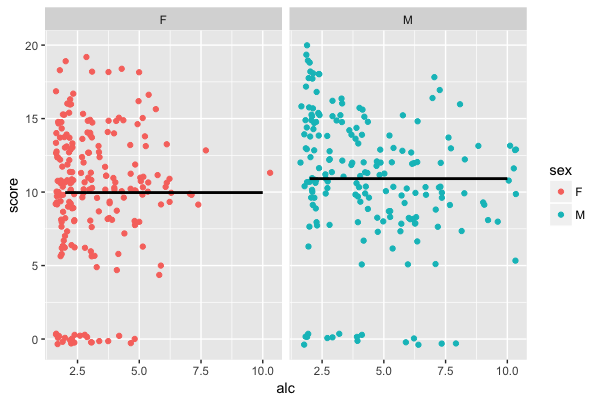

# Additive models

Formula `y ~ alc + sex` translates to

- $score = a_1 + a_2 \cdot alc + a_3 \cdot sexM$, where $sexM = \begin{cases} 1 &\text{if "M"}, \\ 0 &\text{if "F"}. \end{cases}$
- $score = a_1 + a_2 \cdot alc$ if female
- $score = (a_1 + a_3) + a_2 \cdot alc$ if male
- Same gradient, different intercept

# Models with interaction

Formula `y ~ alc * sex` translates to

- $score = a_1 + a_2 \cdot alc + a_3 \cdot sexM + \color{blue}{a_4 \cdot alc \cdot sexM}$, where $sexM = \begin{cases} 1 &\text{if "M"}, \\ 0 &\text{if "F"}. \end{cases}$
- $score = a_1 + a_2 \cdot alc$ if female
- $score = (a_1 + a_3) + (a_2 + a_4) \cdot alc$ if male
- Different gradient, different intercept

# Summary of the course

- Variable types
- Basic objects in R (vectors, matrices, data frames)
- Plotting data with `ggplot2`
- Transforming and joining data with `dplyr`
- Importing and exporting data
- R projects, R scripts and R markdown
- Making maps
- Basic statistical testing and modeling

# Where do we go from here?

- Read [R for Data Science](http://r4ds.had.co.nz/) from cover to cover!
- Take short courses on [DataCamp](https://www.datacamp.com/onboarding/learn?from=home&technology=r)
- Learn more R with [`swirl`](http://swirlstats.com/)
- Writing your own functions and running simulations
- Advanced mapping with `ggmap`
- Advanced regression models with `glmnet`
- Interactive web apps with `shiny`
- Text analysis with `tidytext`
  - Recommmended text: *Text Mining with R* by Julia Silge and David Robinson (avaible online for free at [tidytextmining.com](http://tidytextmining.com/))

# Other Stanford courses

- Programming: CS 106A
- Statistical methods: STATS 60, STATS 101

# Thank you! :)